# Diffusion Curve Generator Output

09 January, 2019

# 1. Introduction

The method takes probability distributions for three diffusion parameters to generate curves based on the Bass Model of Product Diffusion. The parameters, $m$, $N1$ and $t'$, represent the maximum number of adoptions attained, the number of adoptions in the first year and the time at which the rate of diffusion reduces, respectively.

# 2. Elicitation Input

Input distributions

```
##      Expert                        M                   N1               t'
## 1: Expert A  Triangle(54.2, 10, 150)  Triangle(2.3, 0, 5) Normal(5.1, 1.5)
## 2: Expert B Triangle(158.8, 30, 230) Triangle(5.7, 2, 15) Normal(9.9, 1.5)
## 3: Expert C Triangle(204.4, 30, 410) Triangle(7.1, 2, 10) Normal(3.5, 1.1)
```

Distributions of the input parameters (200 samples). The parameters were sampled from mixture distributions.

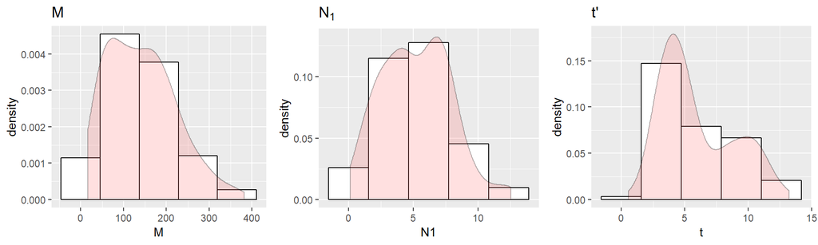

Summary of sample input parameters

```
##        M                N1                t
##  Min.   : 17.02   Min.   : 0.1441   Min.   : 0.5795
##  1st Qu.: 74.65   1st Qu.: 3.1276   1st Qu.: 3.7025
##  Median :132.61   Median : 5.1038   Median : 4.8674
##  Mean   :142.08   Mean   : 5.2299   Mean   : 5.9217
##  3rd Qu.:193.85   3rd Qu.: 7.1755   3rd Qu.: 8.3941
##  Max.   :382.04   Max.   :12.5132   Max.   :13.2143
```

# 3. Parameter fitting

Distributions of the fitted parameters (200 samples).

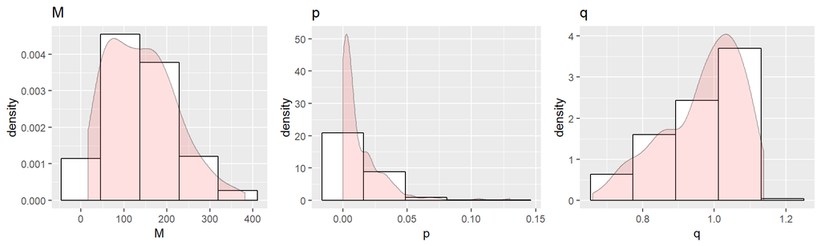

```
##        M                p                   q
##  Min.   : 17.02   Min.   :0.0001432   Min.   :0.6611
##  1st Qu.: 74.65   1st Qu.:0.0015991   1st Qu.:0.8889
##  Median :132.61   Median :0.0062273   Median :0.9945
##  Mean   :142.08   Mean   :0.0131181   Mean   :0.9690
##  3rd Qu.:193.85   3rd Qu.:0.0191562   3rd Qu.:1.0556
##  Max.   :382.04   Max.   :0.1298799   Max.   :1.1371
```

# 4. Generated diffusion curves

Generated diffusion curves.

- $N(t)$ Number of cumulated adoptions at $t$
- $dN(t)$ New adoptions at $t$

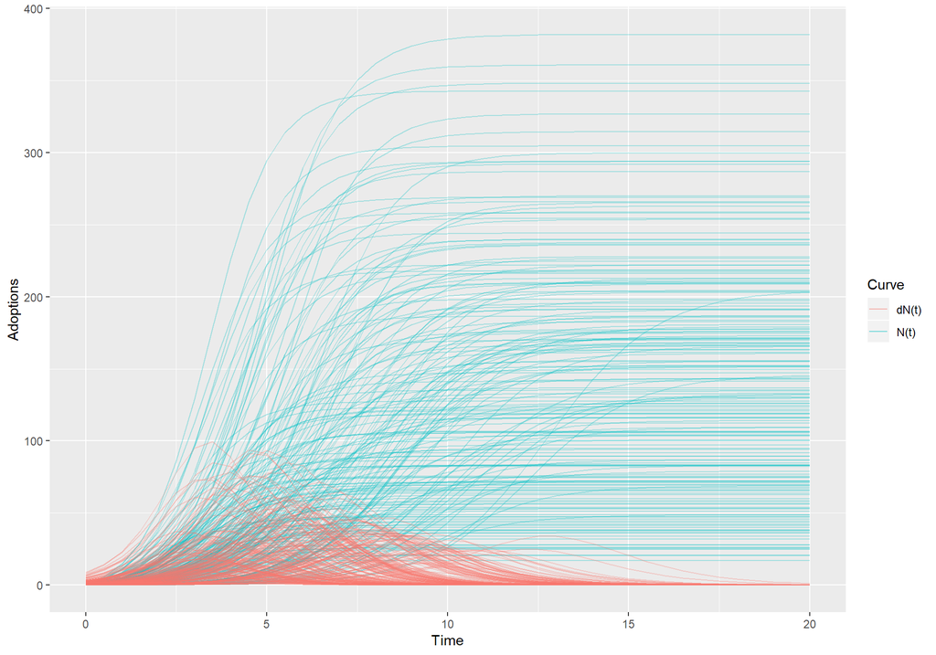

Mean curves

[output not shown]

## Reference

Grimm SE, Stevens JW, Dixon S. Estimating Future Health Technology Diffusion Using Expert Beliefs Calibrated to an Established Diffusion Model. Value Health. 2018 Aug;21(8):944-950.